# Reproducible Research: Peer Assessment 1

## Loading and preprocessing the data

First let us load the data inro R (we are assuming that the data have been unzipped). Besides, we’ll add week days to the data because we are going to use week days later in our analysis anyway. At the same time, we’ll load the libraries.

```r
library(plyr)
library(ggplot2)
raw.data <- read.csv("activity.csv")
raw.data$week.day <- format(as.Date(raw.data$date), format="%a")
```

## What is mean total number of steps taken per day?

We are going to create a new data set with the mean and the median number of steps per day. We’ll use the function *ddply* from the library *plyr*. The new data frame *total.steps* has the following columns:

- *date*
- *total* - the overall number of steps

To ignore the missing values (as required in the assignment), we set the option “na.rm=TRUE”. Then we plot a histogram of the total number of steps. Since we essentially replaced missing values with zeroes (because we just skipped them when calculating the sum), a large amount of zeroes in the histogram has been generated.

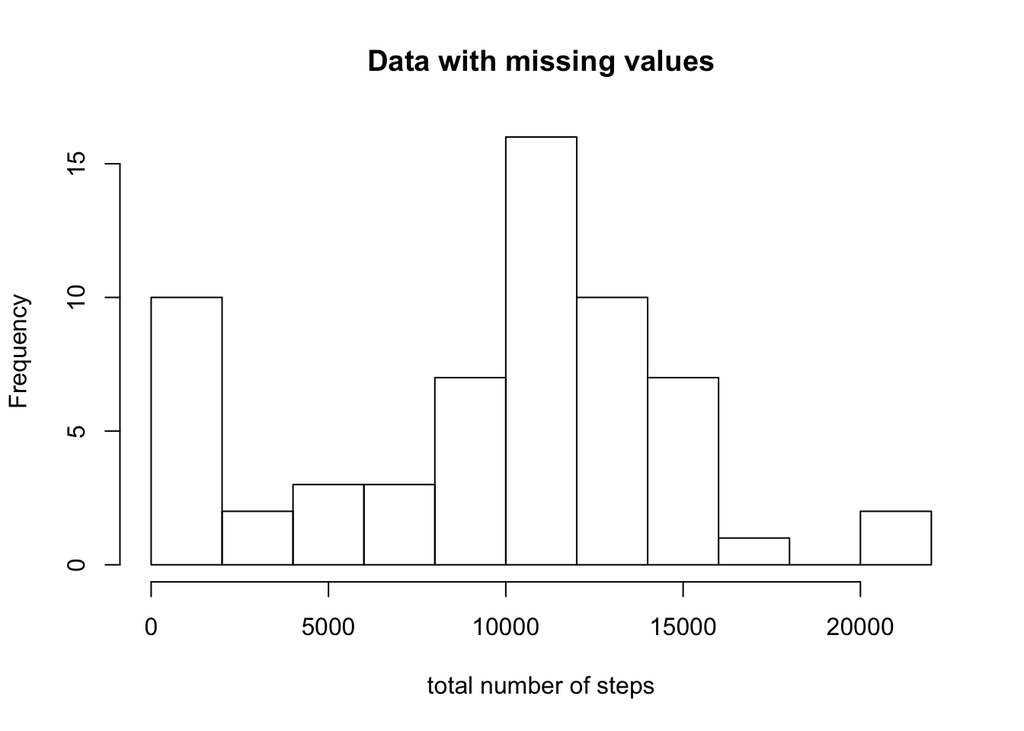

```r
total.steps <- ddply(raw.data, .(date), summarize,
                     total=sum(steps,na.rm=TRUE))
hist(total.steps$total,breaks=12,main="Data with missing values",
     xlab="total number of steps")
```

Now we calculate the mean and the median of the total steps.

```r
mean.and.median <- c(mean(total.steps$total),
                     median(total.steps$total))
mean.and.median
```

```
## [1]  9354 10395
```

The mean of the total number of steps per day (for days where it is known) is 9354.2295 and the median is 1.0395 × 10<sup>4</sup>.

## What is the average daily activity pattern?

First, we create a data frame called *average.steps* with the following columns

- *interval* - a 5-minutes interval
- *num* - average number of steps for the given interval across all days.

At the same time, *most.active* is the interval with most average steps across all days.

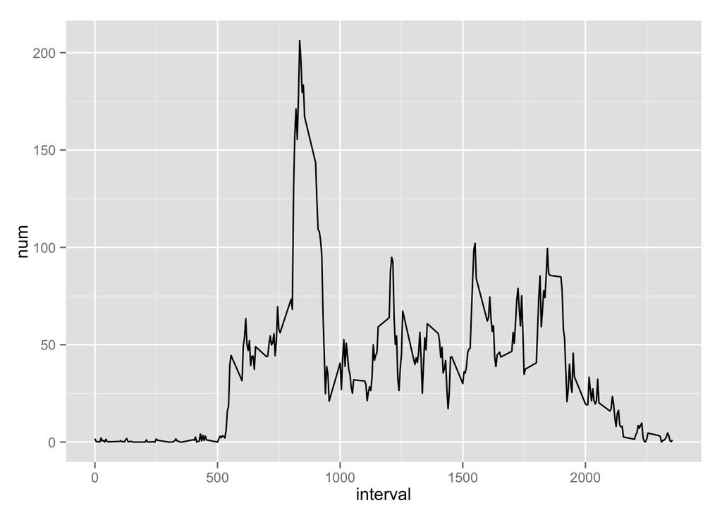

```r
average.steps <- ddply(raw.data, .(interval), summarize,
                       num=mean(steps,na.rm=TRUE))
most.active <- which.max(average.steps$num)
qplot(interval,num,geom="line",
      data=average.steps)
```

The interval with most steps on the average is 835.

## Imputing missing values

We are going to calculate the average for this interval per week day and use it to replace missing values.

1. To calculate the total number of missing values in the data set, we are only interested in the column *steps*, so we’ll use the function *is.na*:

```r
no.missing.values <- sum(is.na(raw.data$steps))
```

The number of missing values is 2304.

2. We calculate the average number of steps for each interval and week day and replace missing values with the average for the same interval and the same week day. The resulting data frame is *average.steps*.

```r
average.steps <- ddply(raw.data, .(interval, week.day), summarize,
                       num=mean(steps,na.rm=TRUE))
```

3. We create a new data frame called *complete.data*, copy *raw.data* into it, and then replace all missing values in the for loop.

```r
complete.data <- raw.data
for (i in 1:nrow(complete.data)) {
        if (is.na(complete.data$steps[i])) {
                I <- complete.data$interval[i]
                D <- complete.data$week.day[i]
                tmp <- subset(average.steps,
                              (week.day==D)&(interval==I))
                complete.data$steps[i] <- tmp$num
        }
}
```

4. Now we make a histogram of the data with missing values that have been filled in.

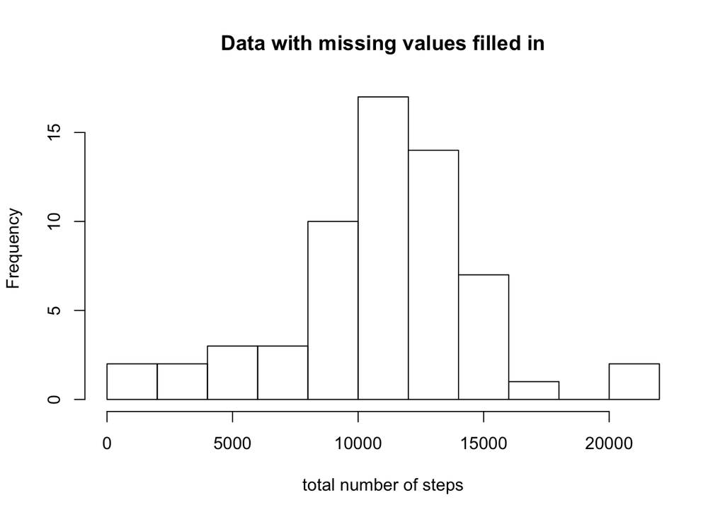

```r
total.steps <- ddply(complete.data, .(date), summarize,
                     total=sum(steps,na.rm=TRUE))
hist(total.steps$total,breaks=12,
     main="Data with missing values filled in",
     xlab="total number of steps")
```

Now we’ll calculate the mean and the median of the data with missing values filled in:

```r
new.mean.and.median <- c(mean(total.steps$total,na.rm=TRUE),
                     median(total.steps$total,na.rm=TRUE))
new.mean.and.median
```

```
## [1] 10821 11015
```

Now the mean of the total number of steps per day is 1.0821 × 10<sup>4</sup> and the median is 1.1015 × 10<sup>4</sup>.

Recall that for the data with missing values, the mean was 9354.2295 and the median was 1.0395 × 10<sup>4</sup>.

As we see, both the mean and the median became bigger and a lot of zeroes have been gone as can be seen from the comparison of the two histograms. My explanation is that ignoring the missing values in the first part of the assignment, we essentially replaced them with zeroes. Now we replaced missing values with positive numbers instead, so, obviously, they grew on the average.

## Are there differences in activity patterns between weekdays and weekends?

First, we are going to add a factor column called *day* to the data frame *complete.data*. There could be a better way to do it, but I haven’t been getting much sleep recently and now it’s too late and I really need to submit it and go to bed:

```r
complete.data$day <- complete.data$week.day
complete.data[complete.data$week.day=="Mon",]$day <- "weekday"
complete.data[complete.data$week.day=="Tue",]$day <- "weekday"
complete.data[complete.data$week.day=="Wed",]$day <- "weekday"
complete.data[complete.data$week.day=="Thu",]$day <- "weekday"
complete.data[complete.data$week.day=="Fri",]$day <- "weekday"
complete.data[complete.data$week.day=="Sat",]$day <- "weekend"
complete.data[complete.data$week.day=="Sun",]$day <- "weekend"
complete.data$day <- factor(complete.data$day)
```

Now we’ll calculate the average number of steps per day, factoring by weekend/weekday and then plot the result.

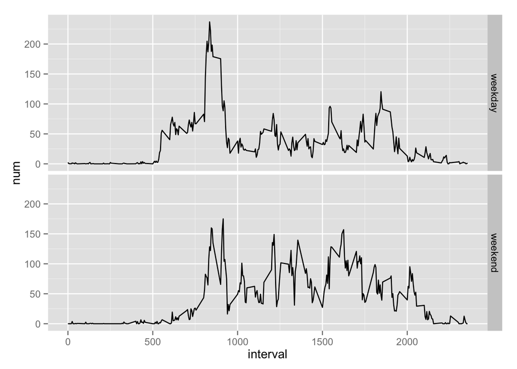

```r
average.steps <- ddply(complete.data, .(interval, day), summarize,
                       num=mean(steps,na.rm=TRUE))
qplot(interval,num,geom="line",
      data=average.steps,facets=day~.,)
```